# Gamma Clustering

To get started, load the “GammaClustering” library

```r
library(GammaClustering)
```

The gamma clustering algorithm requires a log2(fold change) matrix of dimensions (n_genes, n_samples). Here, we create such a matrix starting from differential expression data obtained from DESeq2.

```r
# Read in the source data
fc <- read.csv("../../fold_change.csv", row.names=1)
pvals <- read.csv("../../adj_p.csv", row.names=1)

# Filter genes by p < 0.05 and |FC|>1.5 in at least one mouse strain
fc[is.na(fc)]=0
pvals[is.na(pvals)]=1
keep <- which(apply((pvals<0.05)*(abs(fc)>log2(1.5)),1, any))
x <- as.matrix(fc[keep,])
dim(x)
```

```
#> [1] 932  14
```

To run any of the analysis for gamma clustering, we need to create a gmatrix object. Conventionally, gene clustering has been performed on the “Pearson Distance,” which is just one minus the correlation coefficient. The equivalent here is to set squared=FALSE.

```r
# Create a gmatrix object that does not square correlation coefficients
gm <- gmatrix(x, squared=FALSE)
```

Gamma clustering begins with n “seeds”, which are a set of genes from which clustering begins. In practice, n reflects an upper bound on the number of clusters that will be identified. To find the optimal value of n, we take the value that maximizes the average clustering certainty. This is similar to the silhouette method that is often used in similar contexts.

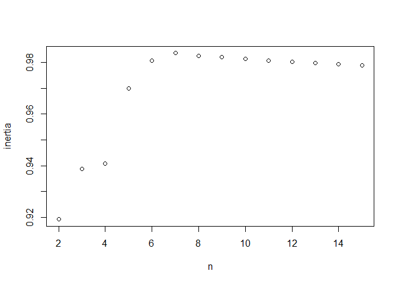

```r
# Test values of n from 2 to 15
gctest(2, 15, gm)
```

As shown, the optimal value of n is 7. Next, we run gamma clustering using this parameter and visualize the clustering with Uniform Manifold Approximation and Projection (UMAP).

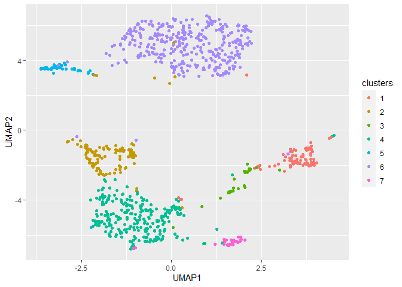

```r
clust <- gcluster(gm, n=7)
clust.labels <- clust$labels
gammaplot(gm, clust.labels)
```

Genes belonging to a cluster can be readily obtained using the cluster labels. From there, gene ontology and pathway analysis can be considered.

```r
# Obtain a list of genes in cluster #3
rownames(x)[clust.labels==3]
```

```
#>  [1] "Cox8b"         "Cyp1a1"        "Nptx1"         "Cyp1a2"
#>  [5] "Chst11"        "Ntrk2"         "Ighg2c"        "Pmm1"
#>  [9] "Htatip2"       "Slc46a3"       "Cyfip2"        "Snhg11"
#> [13] "Zfp759"        "Myc"           "Cidec"         "Gm17494"
#> [17] "4930562F07Rik" "Nfe2l2"        "Pcp4l1"        "Rgs2"
#> [21] "Ugt2b35"       "Cd36"          "Slc38a4"       "Cyb5a"
#> [25] "Slc7a2"        "Nr4a2"         "Maoa"          "Ier3"
#> [29] "Sorcs3"        "Pdss2"         "Nrg4"          "S100a9"
#> [33] "Sult2a2"       "Ighg1"
```

An important aspect of the Pearson Distance is that it only groups together genes by positive correlation. However, negative correlations can also be an indication of gene-gene interactions. Thus, we recommend keeping the default setting of squared=TRUE for gmatrix

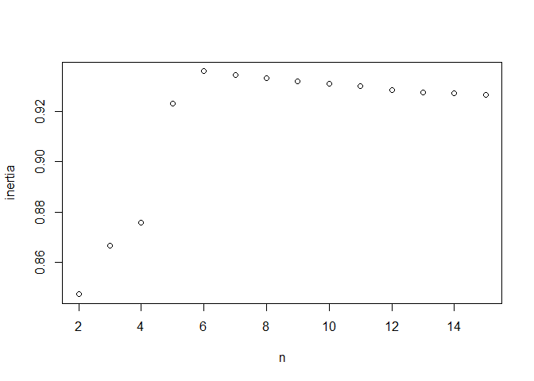

```r
gm <- gmatrix(x)
gctest(2, 15, gm)
```

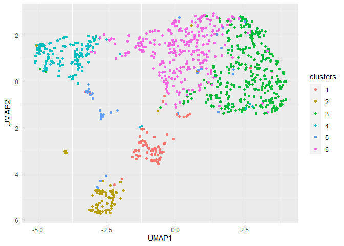

```r
clust <- gcluster(gm, n=6)
clust.labels <- clust$labels
gammaplot(gm, clust.labels)
```

```r
rownames(x)[clust.labels==5]
```

```
#>  [1] "Cyp1a1"             "Cfd"                "Nptx1"
#>  [4] "Klhl31"             "Cyp1a2"             "Ighg2c"
#>  [7] "Pmm1"               "Htatip2"            "Slc46a3"
#> [10] "Cyfip2"             "Ces2c"              "ENSMUSG00000089681"
#> [13] "Fam25c"             "Myc"                "Gm17494"
#> [16] "Nfe2l2"             "Pcp4l1"             "Pir"
#> [19] "Ugt2b35"            "Cd36"               "Maz"
#> [22] "Cyb5a"              "Enho"               "Ier3"
#> [25] "Tgfbr2"             "Myl3"               "Sorcs3"
#> [28] "Pdss2"              "Serpina11"          "Plekhh3"
#> [31] "Nrg4"               "Acox1"              "Hspb7"
#> [34] "Tmem97"             "Dio1"               "Arrdc2"
#> [37] "Nrap"               "Sult2a2"            "Sult2a1"
#> [40] "Sult2a3"            "mt-Co2"
```

Now that genes have been clustered, we can consider the relationship between these clusters and observable phenotypes. Here, the file “phenotypes.csv” contains the TCDD burden, change in fat percentage, and change in body weight gain for each of the mouse strains studied.

```r
phen <- as.matrix(read.csv("../../phenotypes.csv", row.names=1))
ph_plus_g <- rbind(phen, x)
```

The conventional approach to obtaining a p-value for a correlation assumes two normal distributions. However, in our data, we are specifically looking at differentially expressed genes. This means that the distributions being correlated are not necessarily random. Hence, we can do a permutation test to obtain more reliable p-values based on the null hypothesis that the two genes are both DEGs in at least one mouse strain. This permutation test shuffles the entire data set, so only a few iterations are needed for consistent results. To ensure reproducible results, we must also seed the random number generation to start.

```r
set.seed(2)
ph_gm <- gmatrix(ph_plus_g, permuted=5)
```

From this matrix, and the previous clustering, we can look at the maximum likelihood path and the path of maximum information flow for TCDD burden to change in fat percentage.

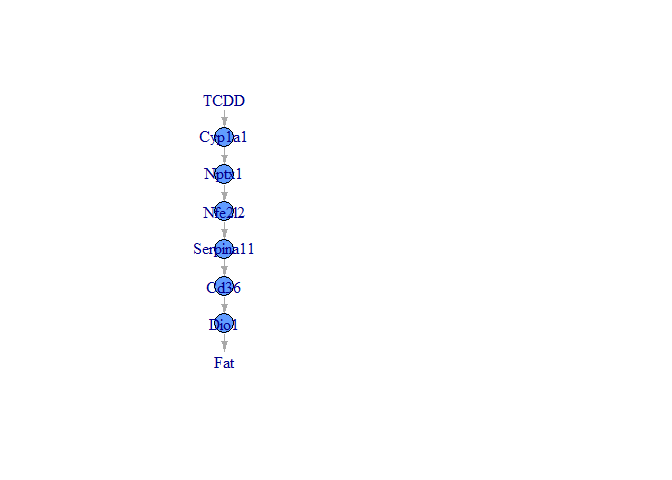

```r
gc_path("TCDD", "Fat", ph_gm, clust.labels)
```

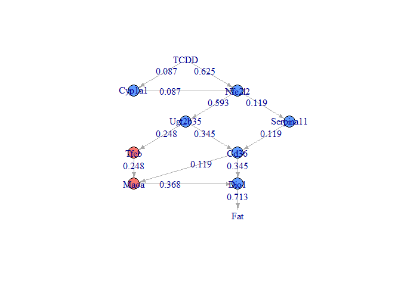

```r
gc_max_flow("TCDD", "Fat", ph_gm, clust.labels)
```

Of course, correlation does not imply causation, and a number of confounding factors may explain observed correlations. Toward this end, gamma clustering offers a few ways to correct for some of these confounding factors. * Partial correlations: This lessens the correlation between two genes that are in fact separately correlated to an auxiliary gene(s) instead. * Quantile normalization: This lessens the confounding, population effects, such as one mouse strain showing more differential expression than the others. * Distance matrix: The membership of a gene to a cluster reflects the correlation to all genes in the cluster instead of the nearest gene in the cluster. Although this aggregate effect is less sensitive to outliers, it is often the case that any “real” correlation is an interesting correlation, and these may be buried using this method.

```r
gm <- gmatrix(x, partial=TRUE, normalization=TRUE)
```

```
#> Estimating optimal shrinkage intensity lambda (correlation matrix): 0.7354
```

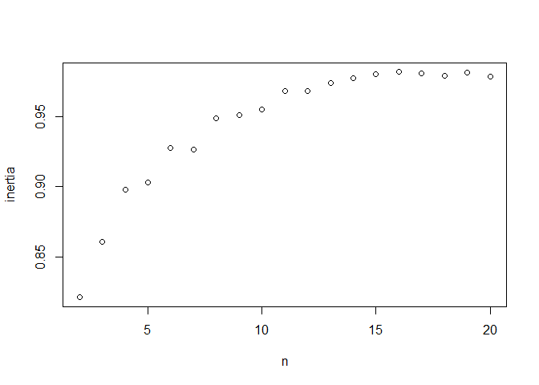

```r
gctest(2, 20, gm, method="distance")
```

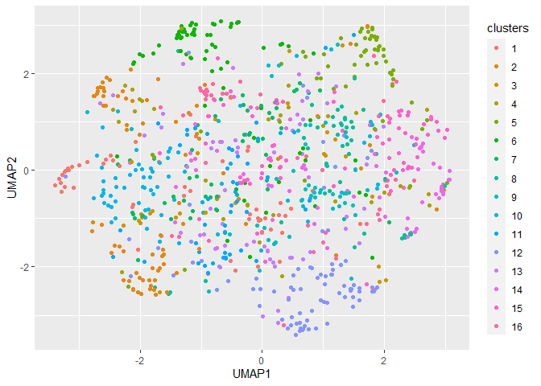

```r
clust <- gcluster(gm, n=16, method="distance")
clust.labels <- clust$labels
gammaplot(gm, clust.labels)
```

```r
set.seed(2)
ph_gm <- gmatrix(ph_plus_g, permuted=5, partial=TRUE, normalization=TRUE)
```

```
#> Estimating optimal shrinkage intensity lambda (correlation matrix): 0.7357
#>
#> Estimating optimal shrinkage intensity lambda (correlation matrix): 0.9251
#>
#> Estimating optimal shrinkage intensity lambda (correlation matrix): 0.9234
#>
#> Estimating optimal shrinkage intensity lambda (correlation matrix): 0.9216
#>
#> Estimating optimal shrinkage intensity lambda (correlation matrix): 0.9241
#>
#> Estimating optimal shrinkage intensity lambda (correlation matrix): 0.9239
```

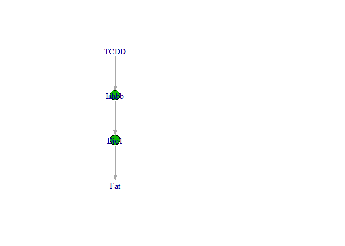

```r
gc_path("TCDD", "Fat", ph_gm, clust.labels)
```

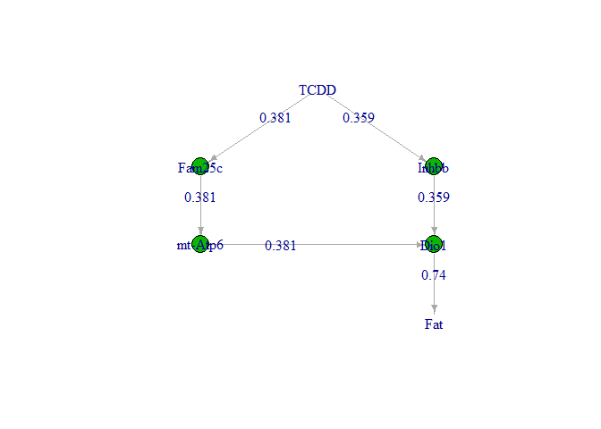

```r
gc_max_flow("TCDD","Fat",ph_gm, clust.labels)
```

As cluster 6 appears significant in connecting TCDD burden to fat percentage, can look at what genes are present in this cluster

```r
# Find the genes present in cluster 6
rownames(x)[clust.labels==6]
```

```
#>  [1] "Mup7"               "Gm12718"            "Nptx1"
#>  [4] "Fitm1"              "Nrtn"               "Sh3bgr"
#>  [7] "Apoa1"              "Gstp1"              "ENSMUSG00000045999"
#> [10] "Alas2"              "Ttc39c"             "Epop"
#> [13] "Limch1"             "Eva1b"              "Sds"
#> [16] "Apoe"               "Zfp771"             "Plbd2"
#> [19] "Crlf2"              "Gm15690"            "Tmem132e"
#> [22] "Mettl26"            "Rabac1"             "Map1lc3a"
#> [25] "Fam25c"             "Gm12473"            "mt-Atp6"
#> [28] "ENSMUSG00000086869" "Apoc3"              "Ldb1"
#> [31] "C1qtnf1"            "Uap1l1"             "Nfe2l2"
#> [34] "Fuom"               "Ugt2b35"            "Cadm3"
#> [37] "Rarg"               "Col4a1"             "Gm11946"
#> [40] "Tfeb"               "Cd36"               "Maz"
#> [43] "Rab9"               "Fhl1"               "Gm11696"
#> [46] "Rnf7"               "Pygm"               "Enho"
#> [49] "Emilin1"            "Maoa"               "Gm15756"
#> [52] "Serpina1a"          "Gatad2b"            "Tpm1"
#> [55] "Etfrf1"             "Spata2l"            "Gm11748"
#> [58] "Pdss2"              "Gm16548"            "Cdk5"
#> [61] "Serpina11"          "Plekhh3"            "6530402F18Rik"
#> [64] "Pwwp2b"             "Inhbb"              "1700084C06Rik"
#> [67] "Pdp2"               "E130114P18Rik"      "Ankrd23"
#> [70] "Dio1"               "ENSMUSG00000087282" "Sult2a2"
```

Interestingly, many of the genes identified with the unadjusted methodology still show up in this cluster. Finally, we can ask whether any genes in the cluster have a significant, overall correlation to other genes in the cluster.

```r
# Find the most central genes in cluster 6
rownames(x)[clust.labels==6 & clust$pvals < 0.05]
```

```
#> [1] "mt-Atp6" "Enho"    "Inhbb"   "Dio1"    "Sult2a2"
```